# Report

Peterson Oliveira

1 - Summarize for us the goal of this project and how machine learning is useful in trying to accomplish it. As part of your answer, give some background on the dataset and how it can be used to answer the project question. Were there any outliers in the data when you got it, and how did you handle those? [relevant rubric items: “data exploration”, “outlier investigation”]

In 2000, Enron was one of the largest companies in the United States. By 2002, it had collapsed into bankruptcy due to widespread corporate fraud. In the resulting Federal investigation, a significant amount of typically confidential information entered into the public record, including tens of thousands of emails and detailed financial data for top executives. The goal of this project was to build a person of interest identifier. Machine learning can be useful in this task because when building a person identifier tool the starting point is the data that you already have. This data will be used to identify patterns that can lead to some conclusion, for example if a person is a person of interest or not. If we take the Machine Leaning definition gave by Tom Mitchell[1] as: "A computer program is said to learn from experience E with respect to some class of tasks T and performance measure P if its performance at tasks in T, as measured by P, improves with experience E" we find that it is exacly the same work to be done in this project.

Inspecting the dataset available we can obtain some interesting and useful information as:

Number of Data Points: 146

Number of Persons of Interest (POIs): 18

Number of non-POIs: 128

Number of features: 21

The features available for analysis are: ['poi', 'salary', 'deferral_payments', 'total_payments', 'exercised_stock_options', 'bonus','restricted_stock', 'restricted_stock_deferred', 'total_stock_value', 'expenses', 'loan_advances', 'other', 'director_fees', 'deferred_income', 'long_term_incentive']

Total missing values in the dataset: 1358

As shown above we have aproximately 1358 NaN in the dataset. For example we have [SAVAGE FRANK] that has many features without value which can be bad for the classification process. We can not infere values to those features because it can bring some problemas to the final dataset and take us to wrong decisions.

{'salary': 'NaN', 'to_messages': 'NaN', 'deferral_payments': 'NaN', 'total_payments': 3750, 'exercised_stock_options': 'NaN', 'bonus': 'NaN', 'restricted_stock': 'NaN', 'shared_receipt_with_poi': 'NaN', 'restricted_stock_deferred': 'NaN', 'total_stock_value': 'NaN', 'expenses': 'NaN', 'loan_advances': 'NaN', 'from_messages': 'NaN', 'other': 'NaN', 'from_this_person_to_poi': 'NaN', 'poi': False, 'director_fees': 125034, 'deferred_income': -121284, 'long_term_incentive': 'NaN', 'email_address': 'NaN', 'from_poi_to_this_person': 'NaN'}

To draw a better picture of the dataset it is better to use scatterplots or some type of graphical visualization as:

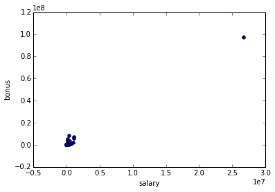

```python
%matplotlib inline

for point in data:
    salary = point[1]
    bonus = point[5]
    matplotlib.pyplot.scatter( salary,bonus )

matplotlib.pyplot.xlabel("salary")
matplotlib.pyplot.ylabel("bonus")
matplotlib.pyplot.show()
```

With the plot help it is easier to understand and visualize the dataset in case the data has some outliers.

An outlier is an observation point that is distant from other observations and can lead to wrong conclusions. An outlier may be due to variability in the measurement or it may indicate experimental error [11].

There is no rigid mathematical definition of what constitutes an outlier and determining whether or not an observation is an outlier is ultimately a subjective exercise. There are various methods of outlier detection.[12] Some are graphical such as normal probability plots and others are model-based as:

- Chauvenet's criterion
- Grubbs' test for outliers
- MMS

For this project I used a graphical approach and ploted the corresponding data to find experimental errors. As shown above there is a point that is too far from the others and in a deeper analysis it is shown with the (pdf) aid that it corresponds to an unecessary data point that must be removed.

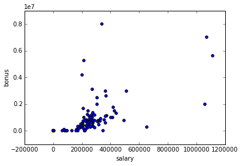

```python
%matplotlib inline

for point in data:
    salary = point[1]
    bonus = point[5]
    matplotlib.pyplot.scatter( salary,bonus )

matplotlib.pyplot.xlabel("salary")
matplotlib.pyplot.ylabel("bonus")
matplotlib.pyplot.show()
```

```python
data_dict.pop("TOTAL", 0 )
```

```
0
```

2 - What features did you end up using in your POI identifier, and what selection process did you use to pick them? Did you have to do any scaling? Why or why not? As part of the assignment, you should attempt to engineer your own feature that does not come ready-made in the dataset -- explain what feature you tried to make, and the rationale behind it. (You do not necessarily have to use it in the final analysis, only engineer and test it.) In your feature selection step, if you used an algorithm like a decision tree, please also give the feature importances of the features that you use, and if you used an automated feature selection function like SelectKBest, please report the feature scores and reasons for your choice of parameter values. [relevant rubric items: “create new features”, “properly scale features”, “intelligently select feature”]

I ended up using the features: ['exercised_stock_options', 'bonus', 'total_stock_value']

To select those features I used the SelectKBest, it selects features according to the k highest scores [2].

To choose between the k values available I experimented with some options from 1 up to 10 and got the best results with k = 3, 5 and 10. To decide which k to choose I used the GridSearchCV algorithm and set the pipeline_params to 'kb__k': [3,5,10].

The selected features K Scores are: exercised_stock_options: 15403.3074318, bonus: 12828.0737791, total_stock_value: 15061.21385553

To split and sort the data I user the StratifiedShuffleSplit with 1000 iterations, a test_size of 0.4 and a random_state of 42. This cross-validation object is a merge of StratifiedKFold and ShuffleSplit, which returns stratified randomized folds. The folds are made by preserving the percentage of samples for each class.[10]

I used the MinMaxScalar to scale and translate each feature individually such that it is in the given range on the training set [3], i.e. between zero and one.

I used the PCA approach which is a linear dimensionality reduction using Singular Value Decomposition of the data and keeping only the most significant singular vectors to project the data to a lower dimensional space[4].

Finally to test all the available options I used the GridSearchCV which is an exhaustive search over specified parameter values for an estimator [5]. with all the transformations combined in a Pipeline to assemble several steps that can be cross-validated together while setting different parameters [6].

To play whith the data I created the total_to_salary feature. This feature is good to analyse thw ratio between how much a person receive from salary compared to the total received. It can give you a hint and blink an alert when someone receive a low salary and big bonuses. To test it I appended it to the feature_list list and tested its K score which is 29.72279702, not so good compared to the bonus feature and some others.

3 - What algorithm did you end up using? What other one(s) did you try? How did model performance differ between algorithms? [relevant rubric item: “pick an algorithm”]

For this project I tested some different algorithms as: KNearestNeighbors, SVC and Naive Bayes. They were choosen based on the flowchart available at the scikit-learn site [7]. The flowchart is designed to give users a bit of a rough guide on how to approach problems with regard to which estimators to try on the data.

The accuracy obtained by the best algorithm (KNearestNeghbors) was: 1.0 (small sample available to develop the code) and 0.85185 with the tester.py dataset. Precision and Recall were also 1.0.

The SVC (with the small sample and PCA) accuracy was: 0.986724137931, but with 1.0 precision and 0.89 recall, which is worst compared with the KNearestNeighbors.

The last one tested was the GaussianNB (with the small sample and PCA) with an accuracy of: 0.897931034483, precision of: 0.62599160056 and recall of: 0.383285714286.

4 - What does it mean to tune the parameters of an algorithm, and what can happen if you don’t do this well? How did you tune the parameters of your particular algorithm? (Some algorithms do not have parameters that you need to tune -- if this is the case for the one you picked, identify and briefly explain how you would have done it for the model that was not your final choice or a different model that does utilize parameter tuning, e.g. a decision tree classifier). [relevant rubric item: “tune the algorithm”]

Tune the parameters is to test different parameters values for the algorithms with the objective of improving its performance for a given dataset.

To tune and test that main combinations I used the GridSearchCV module.

5 - What is validation, and what’s a classic mistake you can make if you do it wrong? How did you validate your analysis? [relevant rubric item: “validation strategy”]

Validation a process to avoid overfitting. It is a common practice when performing a supervised machine learning experiment to hold out part of the available data as a test set X_test, y_test.[8]

Performance of the final algorithm selected is assessed by splitting the data into training and testing sets or through the use of cross validation, noting the specific type of validation performed.

To validate my analysis I used a cross validation separation for the training and testing data, using a shuffle to avoid uniformely distributed labels.

features_train, features_test, labels_train, labels_test = cross_validation.train_test_split(features, labels, test_size=0.4, random_state=42)

6 - Give at least 2 evaluation metrics and your average performance for each of them. Explain an interpretation of your metrics that says something human-understandable about your algorithm’s performance. [relevant rubric item: “usage of evaluation metrics”]

The two evaluation metrics used were precision and recall. In information retrieval, precision is a measure of result relevancy, while recall is a measure of how many truly relevant results are returned. High precision relates to a low false positive rate, and high recall relates to a low false negative rate.[9]

The precision obtained is: 0.53190 and the recall obtained is: 0.30850.

Precision can be seen as how many of the predicted pois are correct and recall is related to how many of the pois does the prediction system returns. A system with high recall but low precision returns many results, but most of its predicted labels are incorrect and a system with high precision but low recall is just the opposite, returning very few results, but most of its predicted labels are correct.